# Priority Queues

## Agenda

1. Motives
2. Naive implementation
3. Heaps
   - Mechanics
   - Implementation
   - Run-time Analysis
4. Heapsort

## 1. Motives

Prior to stacks & queues, the sequential data structures we implemented imposed an observable total ordering on all its elements, which were also individually accessible (e.g., by index).

Stacks & Queues restrict access to elements (to only 1 insertion/deletion point), thereby simplifying their implementation. They don't, however, alter the order of the inserted elements.

Data structures that impose a total ordering are useful — e.g., one that maintains all elements in sorted order at all times might come in handy — but their design and implementation are necessarily somewhat complicated. We'll get to them, but before that ...

Is there a middle ground? I.e., is there a place for a data structure that restricts access to its elements, yet maintains an implied (though not necessary total) ordering?

### "Priority Queue"

Like a queue, a priority queue has a restricted API, but each element has an implicit "priority", such that the element with the highest ("max") priority is always dequeued, regardless of the order in which it was enqueued.

## 2. Naive implementation

```python
class PriorityQueue:
    def __init__(self):
        self.data = []

    def add(self, x):
        # option 1: leave unsorted - O(1)
        # self.data.append(x)

        # option 2: keep sorted (ascending) - O(N)
        i = 0
        while i < len(self.data) and self.data[i] < x:
            i += 1
        self.data.insert(i, x)


    def max(self):
        assert len(self) > 0

        # option 1: linear search for max - O(N)
        # mx = self.data[0]
        # for x in self.data[1:]:
        #     if x > mx:
        #         mx = x
        # return mx

        # option 2: max is at end - O(1)
        return self.data[-1]


    def pop_max(self):
        assert len(self) > 0

        # option 1: linear search for max, then remove - O(N)
        # imx = 0
        # for i in range(1, len(self.data)):
        #     if self.data[i] > self.data[imx]:
        #         imx = i
        # return self.data.pop(imx)

        # option 2: max is at end - O(1)
        return self.data.pop(-1)

    def __bool__(self):
        return len(self.data) > 0

    def __len__(self):
        return len(self.data)

    def __repr__(self):
        return repr(self.data)
```

```python
pq = PriorityQueue()
```

```python
import random
for _ in range(10):
    pq.add(random.randrange(100))
```

```python
pq
```

```
[2, 18, 27, 36, 47, 63, 68, 80, 93, 99]
```

```python
while pq:
    print(pq.pop_max())
```

```
99
93
80
68
63
47
36
27
18
2
```

## 3. Heaps

A heap is an implementation of a priority queue that imposes a *partial ordering* on its contents. A heap takes the form of a *complete binary tree* where every node adheres to the *heap property*, i.e., that the value in a given node is the maximum value in the subtree of which it is the root.

### Mechanics

The heap property is maintained across insertions and removals by way of the "bubble up" and "trickle down" algorithms.

[figure not shown]

Note that the "trickle down" algorithm can also be thought of as a way of "re-heapifying" a tree where all nodes but the root obey the heap property.

### Implementation

```python
class Heap:
    def __init__(self):
        self.data = []

    @staticmethod
    def _parent(idx):
        return (idx - 1) // 2

    @staticmethod
    def _left(idx):
        return idx * 2 + 1

    @staticmethod
    def _right(idx):
        return idx * 2 + 2

    def add(self, x):
        self.data.append(x)

        # bubble up - O(log N)
        idx = len(self.data)-1
        while idx > 0:
            pidx = Heap._parent(idx)
            if self.data[idx] > self.data[pidx]:
                self.data[idx], self.data[pidx] = self.data[pidx], self.data[idx]
                idx = pidx
            else:
                break


    def max(self):
        assert len(self) > 0
        return self.data[0]


    def pop_max(self):
        assert len(self) > 0
        ret = self.data[0]
        self.data[0] = self.data[-1]
        del self.data[-1]

        # trickle down -- "heapify"
        self._heapify(0)
        return ret


    def _heapify(self, idx):
        while idx < len(self):
            lidx = Heap._left(idx)
            ridx = Heap._right(idx)
            maxidx = idx
            if lidx < len(self) and self.data[lidx] > self.data[maxidx]:
                maxidx = lidx
            if ridx < len(self) and self.data[ridx] > self.data[maxidx]:
                maxidx = ridx
            if maxidx != idx:
                self.data[idx], self.data[maxidx] = self.data[maxidx], self.data[idx]
                idx = maxidx
            else:
                break


    def __bool__(self):
        return len(self.data) > 0

    def __len__(self):
        return len(self.data)

    def __repr__(self):
        return repr(self.data)
```

```python
h = Heap()
```

```python
import random
for _ in range(10):
    h.add(random.randrange(100))
```

```python
h
```

```
[78, 77, 72, 72, 76, 30, 19, 11, 45, 37]
```

```python
while h:
    print(h.pop_max())
```

```
78
77
76
72
72
45
37
30
19
11
```

### Run-time Analysis

[figure not shown]

## 4. Heapsort

```python
class Heap(Heap):
    def __init__(self, iterable=None):
        if not iterable:
            self.data = []
        else:
            self.data = list(iterable)
            last_internal_idx = Heap._parent(len(self)-1)
            for i in range(last_internal_idx, -1, -1):
                self._heapify(i)
```

```python
import random
rlst = [random.randrange(100) for _ in range(10)]
heap = Heap(rlst)
rlst, heap.data
```

```
([59, 24, 36, 21, 15, 56, 3, 41, 81, 33],
 [81, 59, 56, 41, 33, 36, 3, 24, 21, 15])
```

```python
while heap:
    print(heap.pop_max())
```

```
81
59
56
41
36
33
24
21
15
3
```

```python
def heapsort(iterable):
    heap = Heap(iterable)
    lst = []
    while heap:
        lst.append(heap.pop_max())
    lst.reverse()
    return lst
```

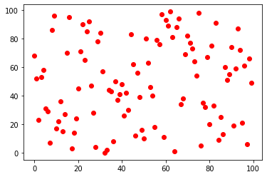

```python
%matplotlib inline
import matplotlib.pyplot as plt
import numpy as np

from random import shuffle
lst = list(range(100))
shuffle(lst)
plt.plot(lst, 'ro');
```

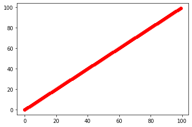

```python
plt.plot(heapsort(lst), 'ro');
```

```python
def insertion_sort(lst):
    for i in range(1, len(lst)):
        for j in range(i, 0, -1):
            if lst[j-1] > lst[j]:
                lst[j-1], lst[j] = lst[j], lst[j-1] # swap
            else:
                break
```

```python
import timeit

def time_insertionsort(n):
    return timeit.timeit('insertion_sort(rlst)',
                         'from __main__ import insertion_sort; '
                         'import random; '
                         'rlst = [random.random() for _ in range({})]'.format(n),
                         number=1)

def time_heapsort(n):
    return timeit.timeit('heapsort(rlst)',
                         'from __main__ import heapsort; '
                         'import random; '
                         'rlst = [random.random() for _ in range({})]'.format(n),
                         number=1)
```

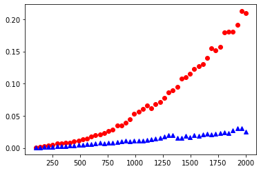

```python
ns = np.linspace(100, 2000, 50, dtype=np.int_)
plt.plot(ns, [time_insertionsort(n) for n in ns], 'ro')
plt.plot(ns, [time_heapsort(n) for n in ns], 'b^');
```

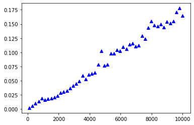

```python
ns = np.linspace(100, 10000, 50, dtype=np.int_)
plt.plot(ns, [time_heapsort(n) for n in ns], 'b^');
```